# Chapter 6 practice problems

## 6H3

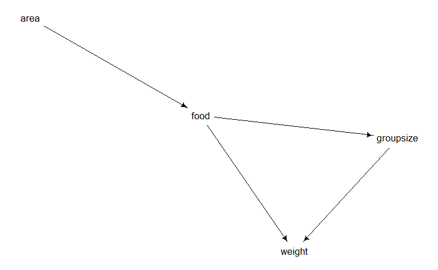

```r
sixm3 <- dagitty( "dag {
area[exposure]
weight[outcome]
area -> food -> weight
area -> food -> groupsize -> weight
}")
drawdag( sixm3)
```

```r
adjustmentSets(sixm3,effect = "direct")
```

```
{ food }
```

```r
impliedConditionalIndependencies(sixm3)
```

```
area _||_ grps | food
area _||_ wght | food
```

### Model definition

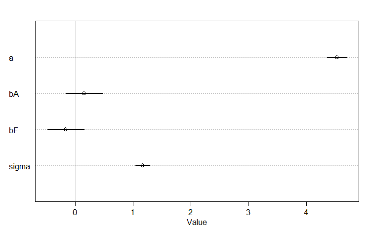

```r
data(foxes)
d <- foxes %>%
  mutate(F = standardize(avgfood),
         G = standardize(groupsize),
         A = standardize(area),
         W = standardize(weight))

m6h3 <- quap(
  alist(
    weight ~ dnorm(mu, sigma),
    mu <- a + bA * A + bF * F,
    a ~ dnorm(mean(d$weight),.5),
    bA ~ dnorm(0,.5),
    bF ~ dnorm(0,.5),
    sigma ~ dexp(1)
  ),data = d
)
precis(m6h3) %>% plot()
```

Increasing the area of a fox’s territory doesn’t appear to have any effect on its weight.

### Prior predictive simulation

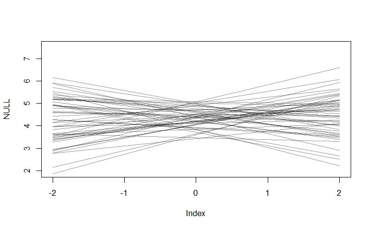

```r
set.seed(10)
prior <- extract.prior( m6h3 )
mu <- link( m6h3 , post=prior , data=list( A=c(-2,2) ) )
plot( NULL , xlim=c(-2,2) , ylim=range(d$weight) )
for ( i in 1:50 ) lines( c(-2,2) , mu[i,] , col=col.alpha("black",0.4) )
```

## 6H4 Direct effect of adding food on weight. Essentially breaks the causal relationships between food, area, and groupsize.

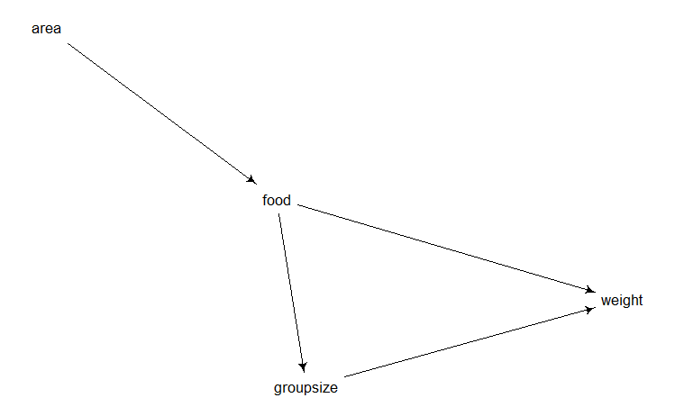

```r
sixh4 <- dagitty( "dag {
food[exposure]
weight[outcome]
area -> food -> weight
area -> food -> groupsize -> weight
}")
drawdag( sixh4)
```

```r
adjustmentSets(sixh4,effect = "direct")
```

```
{ groupsize }
```

```r
impliedConditionalIndependencies(sixh4)
```

```
area _||_ grps | food
area _||_ wght | food
```

### Model definition

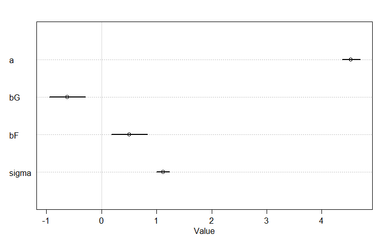

```r
m6h4 <- quap(
  alist(
    weight ~ dnorm(mu, sigma),
    mu <- a + bG * G + bF * F,
    a ~ dnorm(mean(d$weight),.5),
    bG ~ dnorm(0,.5),
    bF ~ dnorm(0,.5),
    sigma ~ dexp(1)
  ),data = d
)
precis(m6h4) %>% plot()
```

Yes, it looks like adding food would have a positive effect on fox weight, mean = .5 SD

### Prior predictive simulation

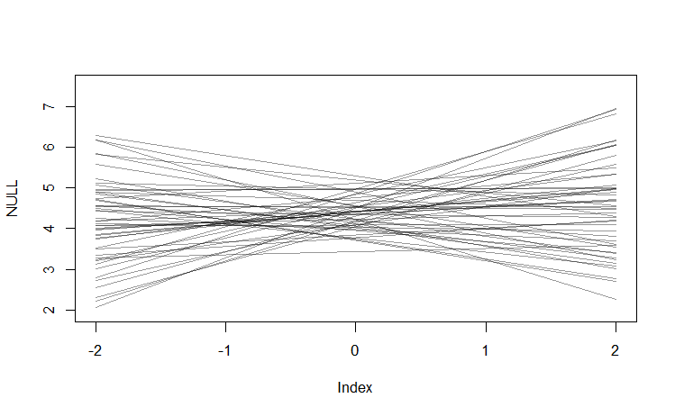

```r
set.seed(11)
prior <- extract.prior( m6h4 )
mu <- link( m6h4 , post=prior , data=list( F=c(-2,2),G = 0 ) )
plot( NULL , xlim=c(-2,2) , ylim=range(d$weight) )
for ( i in 1:50 ) lines( c(-2,2) , mu[i,] , col=col.alpha("black",0.4) )
```

## 6H4 Direct effect of larger group size on weight. Essentially breaks the causal relationships between food, area, and groupsize.

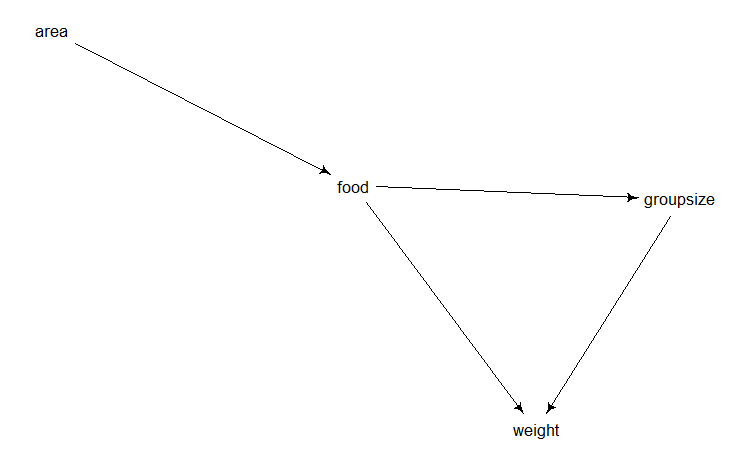

```r
sixh5 <- dagitty( "dag {
groupsize[exposure]
weight[outcome]
area -> food -> weight
area -> food -> groupsize -> weight
}")
drawdag( sixh5)
```

```r
adjustmentSets(sixh5,effect = "direct")
```

```
{ food }
```

```r
impliedConditionalIndependencies(sixh5)
```

```
area _||_ grps | food
area _||_ wght | food
```

### Model definition

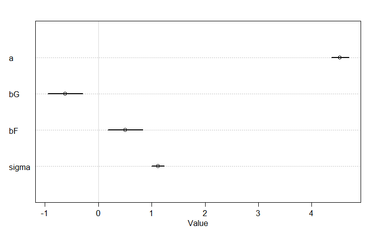

```r
m6h5 <- quap(
  alist(
    weight ~ dnorm(mu, sigma),
    mu <- a + bG * G + bF * F,
    a ~ dnorm(mean(d$weight),.5),
    bG ~ dnorm(0,.5),
    bF ~ dnorm(0,.5),
    sigma ~ dexp(1)
  ),data = d
)
precis(m6h5) %>% plot()
```

Yes, it looks like increasing group size would have a negative effect on fox weight, mean = -.5 SD

### Prior predictive simulation

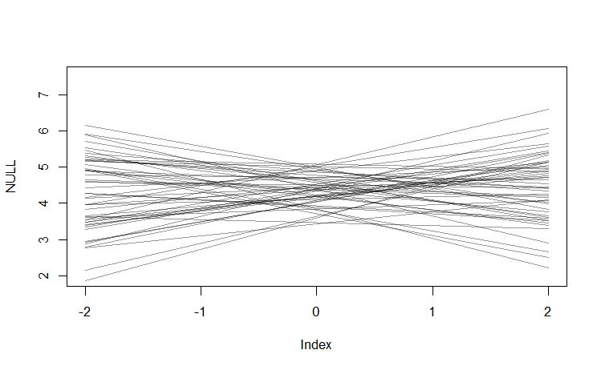

```r
set.seed(10)
prior <- extract.prior( m6h5 )
mu <- link( m6h5 , post=prior , data=list( G=c(-2,2),F = 0 ) )
plot( NULL , xlim=c(-2,2) , ylim=range(d$weight) )
for ( i in 1:50 ) lines( c(-2,2) , mu[i,] , col=col.alpha("black",0.4) )
```